# Computational Statistics 7.2: Bivariate Regression

## Bivariate Regression

### Overview

This lesson introduces bivariate regressions.

### Objectives

After completing this module, students should be able to:

1. Explain the principles of minimum least-squares line.
2. Explain, interpret, and calculate the coefficients in a bivariate regression.
3. Use a bivariate regression to forecast the values of $y$ after observing $x$.

### Readings

Lander, Chapter 19.1. Schumacker, Chapter 16.

## Quantitative Relations

- In the previous lesson we learned how to use the covariance and correlation coefficient to determine if there is a linear relationship between two variables. Moreover, we use the correlation as an standardize indicator of the strength of the relation.
- Now we are going to take a step forward and try to quantify said relation. That is, now we’ll learn the basics of **estimating** how much $y$ changes when $x$ changes. Note that the correlation allows you to answer the questions: **is there a linear relation?**, **is the relation strong or weak**?. But cannot be used directly to say by how much will $y$ change if $x$ changes by some amount. This question is generally referred to the **quantitative relation** between two variables.
- Knowing the quantitative relation between two variables is important because it allow us to: (1) test a quantitative hypothesis, (2) perform forecasts, and, (3) evaluate and design policies and empirical decision mechanisms.
  1. **Testing a quantitative hypothesis**: In general, we are not going to be satisfied by knowing if two variables are related. But we may be more ambitious and use hypothesis testing to test specific values for the relation between two variables. For example, we may not be satisfied by knowing that sleeping improves concentration, but we may want to be interested in determining what amount of sleep is necessary to achieve certain level of concentration.
  2. **Forecasting**: Nobody knows what is going to happen in the future. But, generally we have to make today decisions for which the final outcome depends on what happens in a later date. Should I buy a house this year or wait for the current price bubble tu burst? Should I major in Economics or Engineering?
  3. **Evaluate and design policies**: Knowing if a policy/managerial decision is being effective requires the development of quantitative metrics that allow us to evaluate results objectively. How many jobs are being created/destroyed by $X$ economic policy? By how much is female labor participation increased when the government enforce mandatory maternity leaves?

### Linear Model

- For now, let’s assume that variables $x$ and $y$ are **linearly related**. That relation can be represented by the following linear model:

$$y_{i} = \beta_{0} + \beta_{1} x_{i} + \varepsilon_{i}$$

The model above is implicitly stating the following:

*All the variation of $y_{i}$ can be explained by two factors: (1) **explained variation**, caused by changes in $x_{i}$, and, (2) **unexplained variation**, caued by the changes in $\varepsilon_{i}$*.

- $\varepsilon_{i}$ is all the factors, different from $x_{i}$ that can explain the variation in $y_{i}$. We generally call $\varepsilon_{i}$, the **error term**. Think of the error term as the sum of all other variables that can produce a change in $y_{i}$, but are not explicitly included in the model.
- The parameter $\beta_{1}$ is the **slope** of the model. It captures the quantitative relation between $x$ and $y$. If know the value of $\beta_{1}$, then we can tell by how much will $y$ change when $x$ changes.
- The parameter $\beta_{0}$ is the **intercept** or the **constant term** of the model. It represents the average value of $y_{i}$ when $x_{i}$ is equal to zero.
- In an empirical application we only know the values of $x$ and $y$, with some statistical techniques, we are going to **estimate** the values of $\beta_{0}$ and $\beta_{1}$. The error term is, by definition, not directly observable.
- In a model like this, we call $x_{i}$ the explanatory or the independent variable. And $y_{i}$ is the dependent variable.

### Best-fit (pt 1)

In essence, the regression model is a line equation, the only difference is that we changed the notation for the slope and the intercept, and, we added the error term.

Without the error term, the relation between $x$ and $y$ would be **deterministic** (changes in $y$ can be perfectly determined by changes in $x$). But, because we added the **error term** the relation is **stochastic** (changes in $y$ cannot be perfectly determined by changes in $x$).

Now, let’s simulate some data and visualize the linear model.

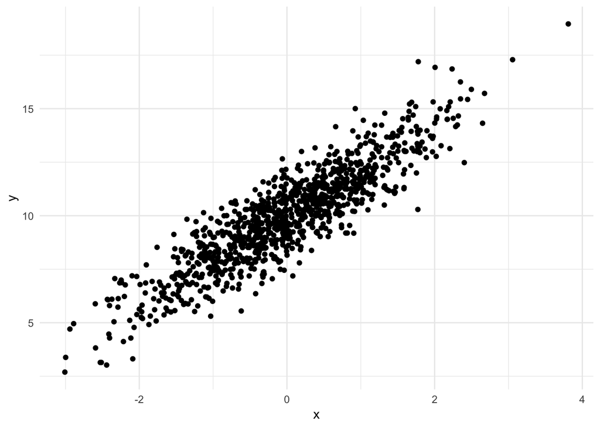

```r
set.seed(1)
n <- 1000 # number of observations

x <- rnorm(n) # Explanatory/Independent Variable
epsilon <-rnorm(n) # Error term

beta0 <- 10 #Intercept parameter
beta1 <- 2  #Slope Parameter

# Linear model
y <- beta0 + beta1*x + epsilon

# data frame
df <- data.frame(x,y)

#Graph
suppressMessages(library(ggplot2))
g1 <- ggplot(data = df, aes(x = x, y = y)) + geom_point() + theme_minimal()
g1
```

### Best-fit (pt 2)

In the simulation we set the values of the intercept $\beta_{0} = 10$ and the slope $\beta_{1} = 2$. In practice we won’t know them, our goal is to correctly guess them.

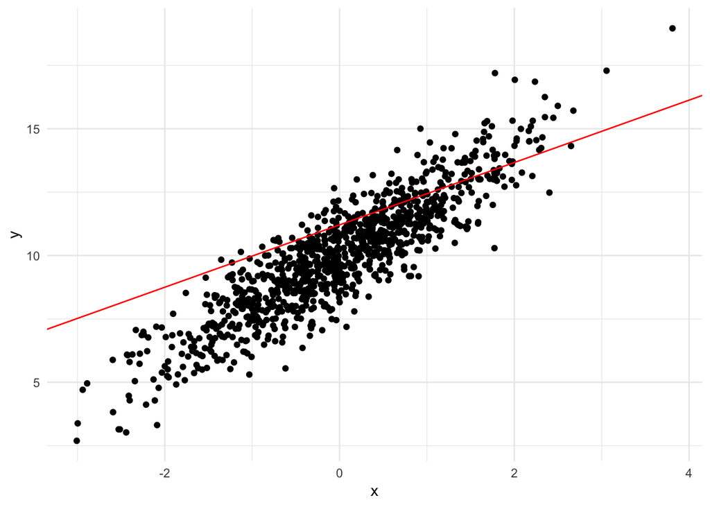

```r
g1 <- g1 + geom_abline(intercept = 11.21,
                       slope = 1.23,
                       color = "red")
g1
```

It looks a bit *off*. Can we do better than this? Let’s try some other values:

### Best-fit (pt 3)

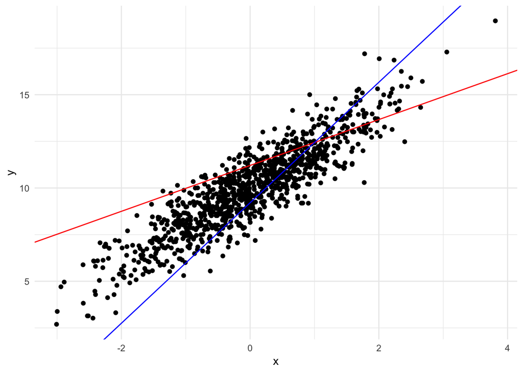

```r
g1 <- g1 + geom_abline(intercept = 9.21,
                       slope = 3.23,
                       color = "blue")
g1
```

Is the blue line a better fit than the red? How can we tell?

### Sum of squared errors (pt 1)

- A model will better estimate the relation between $x$ and $y$ if it fits the data better. That is, if by knowing the variations in $x$, it can correctly determine the corresponding variation in $y$ then the model will, on average, make less mistakes (errors).
- Note that, an error is simply the difference between the observed value of $y$ and the one estimated by the model $\hat{y}$.

$$\epsilon_{i} = y_{i} - \hat{y}_{i}$$

The closer the fitted value $\hat{y}_{i}$, to the actual value of $y_{i}$, the better the estimation and the smaller the error.

Then, our goal is to find the values of $\beta$ that generate the $\hat{y}_{i}$ that minimize the errors.

In particular, we are interested in minimizing the **sum of squared errors** or **SSE**. Minimizing the SSE is preferred to minimizing the errors directly because it penalizes larger error more than smaller ones.

Then, our problem can be formalized as:

$$\text{Min} \;\; \underset{\beta_{0}, \beta_{0}}{SSE} = \sum_{i=1}^{n} \epsilon_{i}^2$$
by definition,

$$\begin{eqnarray*}
\text{Min} \;\; \underset{\beta_{0}, \beta_{0}}{SSE} & = & \sum_{i=1}^{n} \epsilon_{i}^2 \\
& = & \sum_{i=1}^{n} (y_{i} - \hat{y}_{i})^2 \\
& = & \sum_{i=1}^{n} (y_{i} - \beta_{0} - \beta_{1} x_{i})^2 \;\;\;\;\;\; \text{(Using the linear model)}
\end{eqnarray*}$$

### Sum of squared errors (pt 2)

Now, using the SSE we can evaluate the red and blue lines that we initially guessed and then try to find the **optimal** values of the parameters.

```r
#Fitted values of red model
yhat_red <- 11.21 + 1.23*x

#Fitted values of red model
yhat_blue <- 9.21 + 3.23*x

# SSE
sse_red <- sum((y - yhat_red)^2)
sse_blue <- sum((y - yhat_blue)^2)

# What model performs the best?
c(sse_red, sse_blue)
```

```
## [1] 3251.266 3303.368
```

Apparently, the red model fits the data better.

## Ordinary Least Squares

The minimization exercise to derive the OLS parameters can be a bit challenging for those who are not trained in calculus, and, therefore I’ll skip that part. (*For those who enjoy calculus and optimization problems, is a fun little excercise that you can do in a couple of minutes.*)

This is the solution to the estimation of the parameters:

$$\begin{eqnarray*}
\hat{\beta}_{0} & = & \bar{y} - \hat{\beta}_{1} \bar{x} \\
\hat{\beta}_{1} & = & \dfrac{\sum_{i=1}^{n}(x_{i}-\bar{x})(y_{i}-\bar{y})}{\sum_{i=1}^{n}(x_{i}-\bar{x})^2}
\end{eqnarray*}$$

Note that we most know $\hat{\beta}_{1}$ to estimate $\hat{\beta}_{0}$. Also, the formula for $\hat{\beta}_{1}$ can be derived to,

$$\begin{eqnarray*}
\hat{\beta}_{1} & = & \dfrac{\sum_{i=1}^{n}(x_{i}-\bar{x})(y_{i}-\bar{y})}{\sum_{i=1}^{n}(x_{i}-\bar{x})^2} \\
& = & \dfrac{n-1}{n-1}\dfrac{\sum_{i=1}^{n}(x_{i}-\bar{x})(y_{i}-\bar{y})}{\sum_{i=1}^{n}(x_{i}-\bar{x})^2} \\
& = & \dfrac{\sigma_{x,y}}{\sigma_{x}^2}
\end{eqnarray*}$$

Where $\sigma_{x,y}$ is the covariance between $x$ and $y$ and $\sigma_{x}^2$ is the variance of $x$ (the squared standard deviation).

If we estimate the parameters using this formula, the obtained parameters are called **ordinary least squares** parameters or OLS parameters. And the model is called the ordinary least squares **regression model**.

### OLS compared

Let’s see if using the OLS parameters we can improve the performance of the model:

```r
varX <- sd(x)^2 #variance of x
covXY <- cov(x,y) #covariance of x and y

beta1 <- covXY / varX
beta0 <- mean(y) - beta1*mean(x)
c(beta0, beta1)
```

```
## [1] 9.983813 2.006433
```

Wow! that is pretty close to the actual values that we set when generating the data.

Let’s see the SSE of the OLS model compared to the other models,

```r
yhat_ols <- beta0 + beta1*x
sse_ols <- sum((y - yhat_ols)^2)
c(sse_red, sse_blue, sse_ols)
```

```
## [1] 3251.266 3303.368 1080.436
```

We greatly reduced the errors by using OLS. Let’s add the regression line to the graph now,

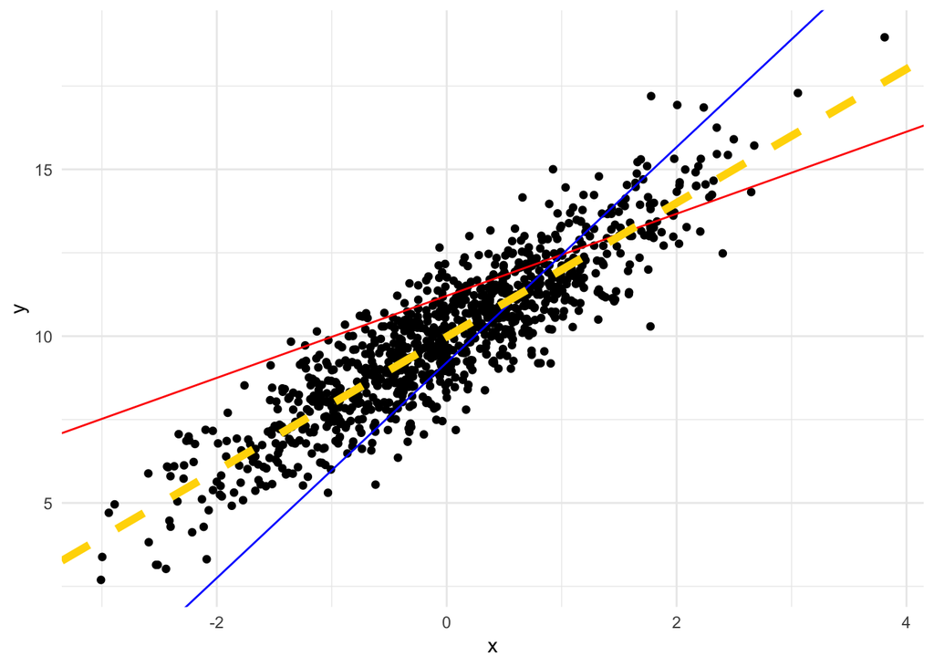

```r
g1 <- g1 + geom_abline(intercept = beta0,
                       slope = beta1,
                       color = "gold",
                       linetype = "dashed",
                       size = 2)
g1
```

### OLS parameters and quantitative relations

Using the OLS parameters we were able to correctly estimate the quantitative relation between $x$ and $y$. The estimated parameters can be interpreted as:

- $\hat{\beta}_{0} =$ `9.9838`, Is the value of the intercept. It represents the value of the $y$ variable when $x$ is equal to zero.
- $\hat{\beta}_{1} =$ `2.0064`, Is the value of the slope. It represents the change in $y$ caused by a change in $x$. If $x$ increase one unit, then $y$ will change by `2.0064` units.

## Empirical Example: Climate Change (again, pt 1)

We are interested in estimating the quantitative relation between C02 emissions and the temperature. Then, we propose the following regression model:

$$y_{i} = \beta_{0} + \beta_{1}x_{i} + \varepsilon_{i}$$

where $y$ represents the temperature and $x$ the C02 emissions. $\varepsilon$ as usual represents the variables that can affect the dependent variable (temperature) that are not included in model and different from the independent variable (C02 emissions).

For this example, we are going to use the `climate_change.csv` dataset - this is the same data from the last lesson -. You can download this from *Course Resources > Datasets*. For reference about the data, take a look at this [link](https://rpubs.com/aashish/ClimateChangeDataAnalysis).

Mind the data definitions! This is how *temperature* is measured in the data:

- Temp: the difference in degrees Celsius between the average global temperature in that period and a reference value. This data comes from the Climatic Research Unit at the University of East Anglia.
- CO2: Atmospheric concentrations of carbon dioxide (CO2). This data comes from the ESRL/NOAA Global Monitoring Division.

Let’s Load the data first,

```r
dataFile <- "/Users/CCD-MAC/Documents/Dropbox NEU/Dropbox/Teaching/NEU/2019/PPUA5301/PPUA5301 - Summer 2019/Lectures/homeworks/homework_assignments/datasets/climate_change.csv"
climate <- read.csv(dataFile)
```

Now, let’s estimate the OLS parameters

```r
x <- climate$CO2
y <- climate$Temp

beta1 <- cov(x, y) / sd(x)^2
beta0 <- mean(y) - beta1*mean(x)

c(beta0, beta1)
```

```
## [1] -3.59314041  0.01059921
```

**Interpretation**

- $\hat{\beta}_{0} =$ `-3.5931`, the average change in the global temperatures, measured in degrees Celsius, would be -3.59 if CO2 is equal to zero. That is, if there were no CO2 emissions in a given year the model predicts that the temperatures would go down by about 3.6 degrees Celsius.
- $\hat{\beta}_{1} =$ `0.0106`, the slope measures the quantitative effect of CO2 emissions on the change in temperature. If the atmospheric concentration of CO2 increase by 1 unit, the change in global temperatures would increase by 0.01 degree Celsius. In other words, the rate in which the planet is warming would increase.

## Empirical Example: Climate Change (again, pt 2)

Now, the fun part. Let’s see how the regression line fits the data.

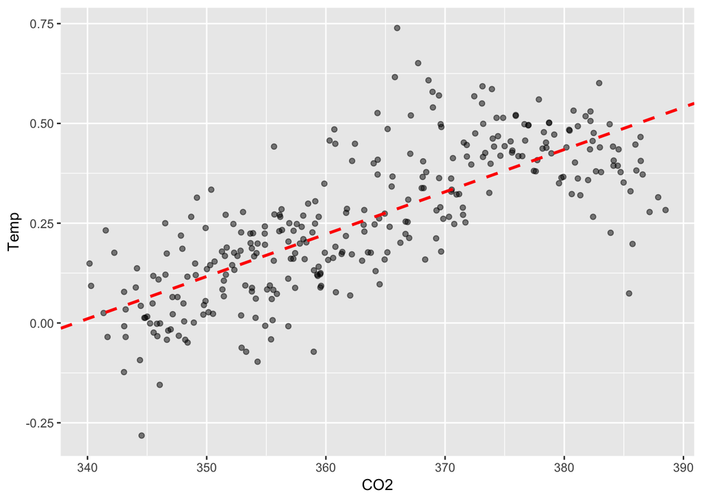

```r
g1 <- ggplot(data = climate, aes(x = CO2, y = Temp)) + geom_point(alpha = 0.5)
g1 <- g1 + geom_abline(intercept = beta0,
                       slope = beta1,
                       color = "red",
                       linetype = "dashed",
                       size = 1)
g1
```

## Empirical Example: Climate Change (predictions)

Now, that we have an estimation of the quantitative relation between $x$ and $y$ we can use it to predict the value of $y$ making some assumptions about $x$.

The data only includes data up to 2008. We’ll use the estimated model to see if we can predict the change in temperature in 2019. According to the Mauna Loa Observatory, the CO2 reading in May was 415.26 ppm.

Using the estimated model we can try to predict the change in temperature for 2019.

```r
x2019 <- 415.26
y2019 <- beta0 + beta1*415.26
y2019
```

```
## [1] 0.8082872
```

According to the model, the change in temperature will increase by 0.8 degree Celsius. Yikes!

As of April 2019, *“April’s temperature departure of 0.93°C (1.67°F) above the 20th century average ranked second to April 2016 (+1.08°C / +1.94°F). April 2019 marks the 412th consecutive month and the 43rd consecutive April with temperatures, at least nominally, above the 20th century average.”* [NOAA](https://www.ncdc.noaa.gov/sotc/global/201904)

Which means that our model is actually not that bad!